# `ggspectra` 0.2.1 User Guide

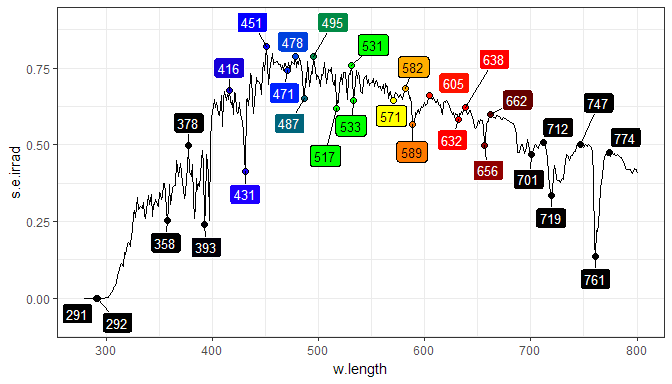

```r
ggplot(sun.spct) + geom_line() +
  stat_peaks(shape = 21, span = 25, size = 2) +
  stat_label_peaks(geom = "label_repel", span = 25,
                   size = 3.5, nudge_y = 0.075, segment.colour = "black") +
  stat_valleys(shape = 21, span = 25, size = 2) +
  stat_label_valleys(geom = "label_repel", span = 25,
                     size = 3.5, nudge_y = -0.075, segment.colour = "black") +
  scale_fill_identity() +scale_color_identity() +
  expand_limits(y = c(-0.08, 0.9))
```

If we do not use a repulsive geom that skips labels set to `""`, the plot produced by `stat_label_peaks` is of little use unless we explicitly skip the unlabelled observations as shown below.

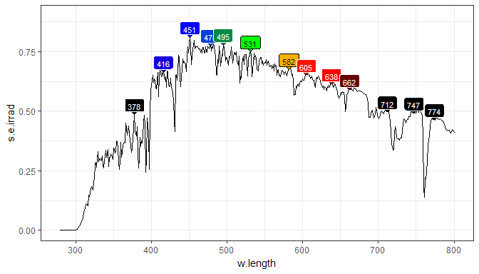

```r
ggplot(sun.spct) + geom_line() +
  stat_peaks(shape = 21, span = 25, size = 2) + scale_fill_identity() +
  stat_label_peaks(geom = "label", span = 25, vjust = "bottom", size = 3,
                   aes(label = ifelse(..is_peak.., ..x.label.., NA)), na.rm = TRUE) +
  scale_color_identity() +
  expand_limits(y = c(NA, 0.9))
```

Setting `span` to `NULL` results in the span set to the range of the data, and so in this case the stat returns the global extreme, instead of a local one. In this case we use geoms `"vline"` and `"hline"` taking advantage that suitable aesthetics are set by the stats.

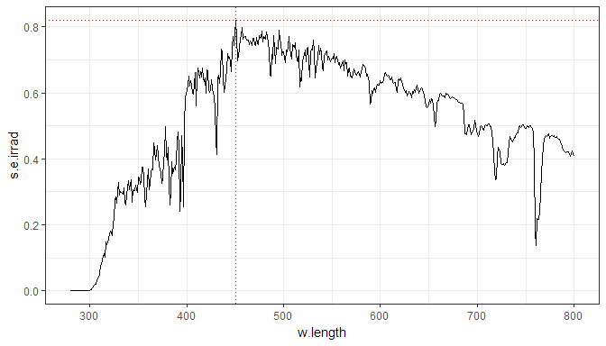

```r
ggplot(sun.spct) + geom_line() +
  stat_peaks(span = NULL, geom = "vline", linetype = "dotted", color = "red") +
  stat_peaks(span = NULL, geom = "hline", linetype = "dotted", color = "red")
```

By default the `label` aesthetic is mapped to a calculated label `..x.label..` giving the wavelength in nanometres. This mapping can be changed to give to a label giving the *y*-value at the peak.

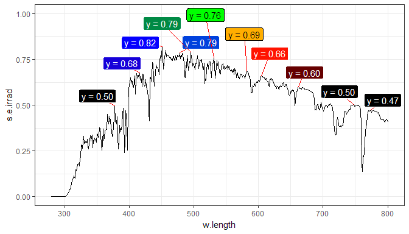

```r
ggplot(sun.spct) + geom_line() +
  stat_label_peaks(span = 31, geom = "label_repel", aes(label = ..y.label..),
             label.fmt = "y = %1.2f", segment.colour = "red",
             min.segment.length = unit(0.05, "lines")) +
  expand_limits(y = 1) +
  scale_fill_identity() + scale_color_identity()
```

As *aesthetics* can use values computed on-the-fly we can even use `paste()` to map a label that combines both values and adds additional text.

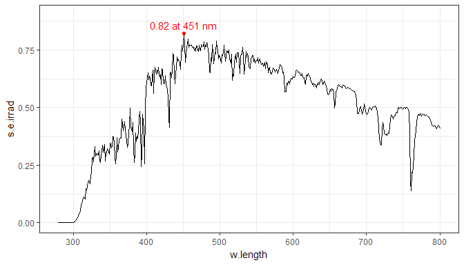

```r
ggplot(sun.spct) + geom_line() +
  stat_peaks(span = NULL, color = "red") +
  stat_peaks(span = NULL, geom = "text", vjust = -0.5, color = "red",
             aes(label = paste(..y.label.., "at", ..x.label.. , "nm"))) +
  expand_limits(y = c(NA, 0.9))
```

Finally we demonstrate that both stats can be simultaneously used. One can also choose to use different spans as demonstrated here, resulting in more maxima being marked by points than labelled with text.

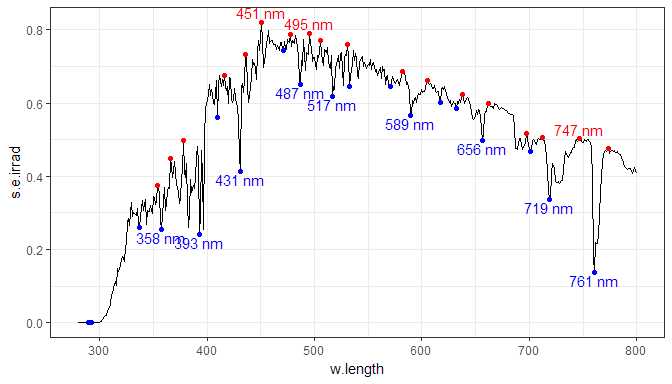

```r
ggplot(sun.spct) + geom_line() +
  stat_peaks(span = 21, geom = "point", colour = "red") +
  stat_valleys(span = 21, geom = "point", colour = "blue") +
  stat_peaks(span = 51, geom = "text", colour = "red",
             vjust = -0.3, label.fmt = "%3.0f nm") +
  stat_valleys(span = 51, geom = "text", colour = "blue",
               vjust = 1.2, label.fmt = "%3.0f nm")
```

This final example shows a few additional tricks used in this case to mark and label the maximum of the spectrum. This example also demonstrates why it is important that these are stats. The peaks are searched and labels generated once for each group, in this case each *facet*.

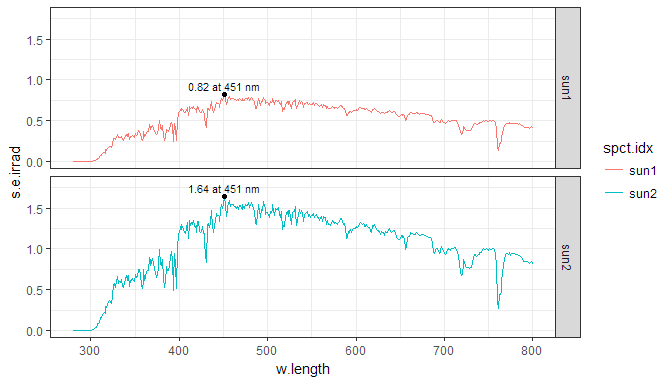

```r
ggplot(two_suns.spct) + aes(color = spct.idx) +
  geom_line() + ylim(NA, 1.8) +
  stat_peaks(span = NULL, color = "black") +
  stat_peaks(span = NULL, geom = "text", vjust = -0.5, size = 3,
             color = "black",
             aes(label = paste(..y.label.., "at", ..x.label.. , "nm"))) +
  facet_grid(spct.idx~.)
```

## Color from wavelength

This stat calculates the colour corresponding to each $x$-value (assumed expressed in nanometres) and adds it to the data. It does not summarize the data like `stat_summary()` nor does it subset the data like `stat_peaks`, consequently the plot does not require any additional *geom* to have all observations plotted. It sets both *color* and *fill* aesthetics to a suitable default.

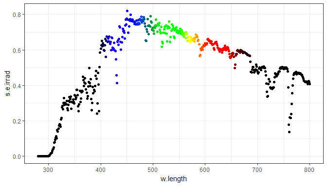

```r
ggplot(sun.spct) +
  stat_color() + scale_color_identity()
```

By use of a filled *shape* and adding a black border by overriding the default *color* aesthetic and over-plotting these point on top of a line, we obtain a better separation from the background.

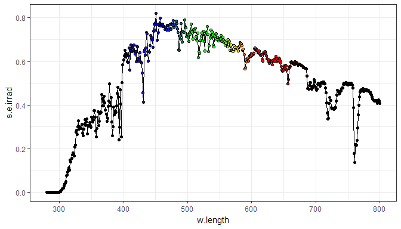

```r
ggplot(sun.spct) +
  geom_line() +
  stat_color(shape = 21, color = "black") +
  scale_fill_identity()
```

With a *trick* using many narrow *bars* we can fill the area under the line with a the calculated colours. This works satisfactorily as the data set has a small wavelength step, as in this case we are using a bar of uniform colour for each wavelength value in the data set.

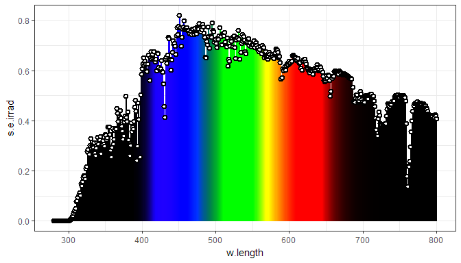

```r
ggplot(sun.spct) +
  stat_color(geom = "bar") +
  geom_point(shape = 21, color = "black", stroke = 1.2, fill = "white") +
  scale_fill_identity() +
  scale_color_identity() +
  theme_bw()
```

As final example we demonstrate a plot with *facets* and *shape* based groups.

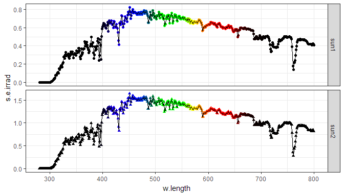

```r
ggplot(two_suns.spct) + aes(shape = spct.idx) +
  stat_color() + scale_color_identity() +
  geom_line() +
  facet_grid(spct.idx~., scales = "free_y")
```

## Averages and similar summaries

Our summary *statistics* are quite different to `ggplot2`s `stat_summary()`. One could criticize that they calculates summaries using a grouping that is not based on a *ggplot* *aesthetic*. This is a deviation from the grammar of graphics but allows the calculation of summaries for an arbitrary region of the range of $x$-values in the spectral data.

### Summaries producing graphical elements

Three *statistics* generate only graphic output. First we demonstrate `stat_wb_box()` that produces a filled box for each waveband, filled with the color corresponding to the waveband.

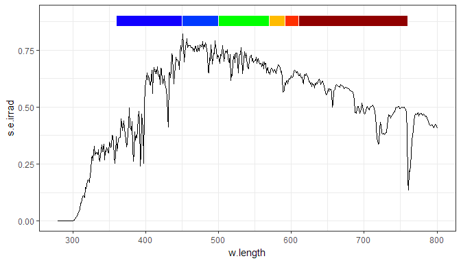

```r
ggplot(sun.spct) + geom_line() +
  stat_wb_box(w.band = VIS_bands(), color = "white") +
  scale_fill_identity()
```

The *statistics* `stat_wb_column` outputs a column for each waveband, with an area equal to the integral for the corresponding region of the spectrum.

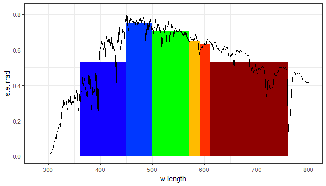

```r
ggplot(sun.spct) + stat_wb_column(w.band = VIS_bands()) + geom_line() +
  scale_fill_identity()
```

The *statistic* `stat_wd_hbar` outputs a horizontal bar showing the mean spectral *y*-value for each waveband.

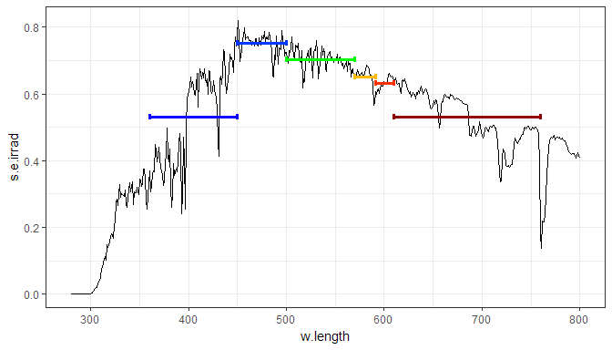

```r
ggplot(sun.spct) + geom_line() +
  stat_wb_hbar(w.band = VIS_bands(), size = 1.2) +
  scale_color_identity()
```

These graphical summaries are frequently used together with text and label elements with names or numerical summaries.

### Name labels

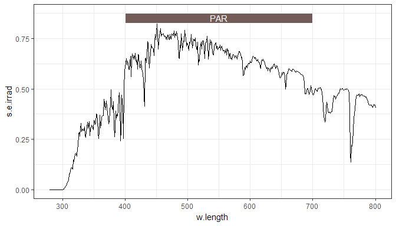

```r
ggplot(sun.spct) + geom_line() +
  stat_wb_box(w.band = PAR(), color = "white", ypos.fixed = 0.85) +
  stat_wb_label(w.band = PAR(), ypos.fixed = 0.85) +
  scale_fill_identity() + scale_color_identity()
```

### Summaries by wavelength range

The summary is calculated for a range of wavelengths, and the `range` argument defaults to the range of wavelengths in each group defined by other aesthetics. The default *geom* is `"text"`.

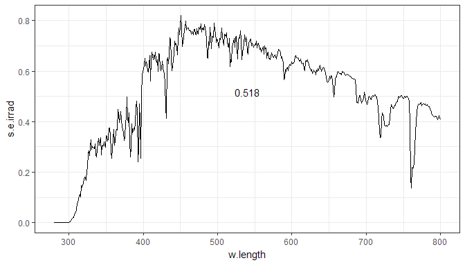

```r
ggplot(sun.spct) + geom_line() + stat_wl_summary()
```

We can optionally supply an argument for `range` to limit the summary to a certain part of the spectrum, in which case the use of the default `"text"` *geom* is misleading. We add the line last so that it is drawn on top of the rectangle.

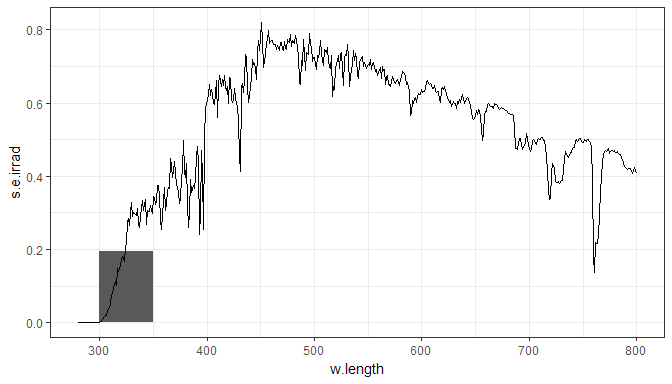

```r
ggplot(sun.spct) +
  stat_wl_summary(range = c(300,350), geom = "rect") +
  geom_line()
```

Here we show how to add horizontal line and label for the overall mean, by adding the same stat twice, using different values for `geom`.

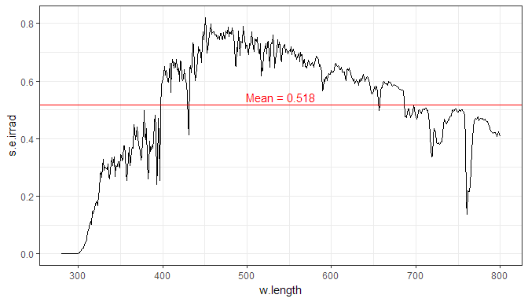

```r
ggplot(sun.spct) +
  geom_line() +
  stat_wl_summary(geom = "hline", color = "red") +
  stat_wl_summary(label.fmt = "Mean = %.3g", color = "red", vjust = -0.3)
```

Or we can add the *aesthetic* twice with two different geoms to get the value plotted as a rectangular area and the value as formatted text. We use `vjust` to move the text above the end of the bar, instead of it being centred on the value itself.

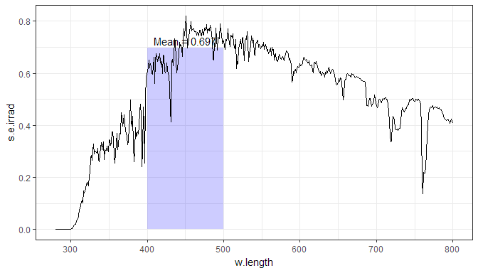

```r
ggplot(sun.spct) +
  stat_wl_summary(range = c(400,500), geom = "rect", alpha = 0.2, fill = color(450)) +
  stat_wl_summary(range = c(400,500), label.fmt = "Mean = %.3g", vjust = -0.3, geom = "text") +
  geom_line()
```

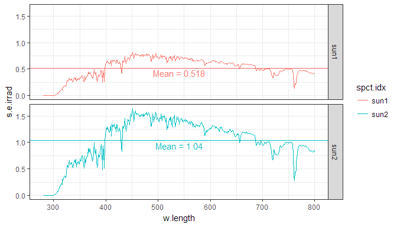

```r
ggplot(two_suns.spct) + aes(color = spct.idx) +
  geom_line() +
  stat_wl_summary(geom = "hline") +
  stat_wl_summary(label.fmt = "Mean = %.3g", vjust = 1.2, show.legend = FALSE) +
  facet_grid(spct.idx~.)
```

Same example as above but using a free scale for $y$, still working as expected.

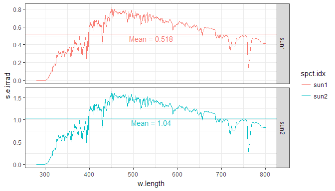

```r
ggplot(two_suns.spct) + aes(color = spct.idx) +
  geom_line() +
  stat_wl_summary(geom = "hline") +
  stat_wl_summary(label.fmt = "Mean = %.3g", vjust = 1.2, show.legend = FALSE) +
  facet_grid(spct.idx~., scales = "free_y")
```

### Means by waveband

Our `stat_wb_mean()` is quite different to `ggplot2`s `stat_summary()`. One could criticize that it calculates summaries using a grouping that is not based on a *ggplot* *aesthetic*. This is a deviation from the grammar of graphics but allows the calculation of summaries for an arbitrary waveband of the spectrum based on `photobiology::waveband` objects, or lists of such objects. In contrast to `stat_wl_summary()` this allows the use of several ranges, and also of different weighting functions. This function returns both mean and total values for each waveband. It differs from `stat_wb_total()` only in the default *aesthetics* set.

The first example uses a `waveband` object created on-the-fly and defining a range of wavelengths.

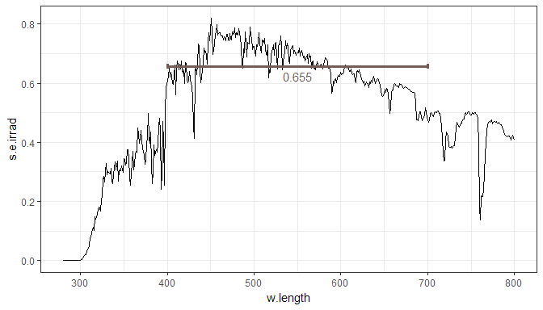

```r
ggplot(sun.spct) +
  geom_line() +
  stat_wb_hbar(w.band = PAR(), size = 1.3) +
  stat_wb_mean(aes(color = ..wb.color..), w.band = PAR(), ypos.mult = 0.95) +
  scale_color_identity() +
  scale_fill_identity() +
  theme_bw()
```

If a numeric vector or a spectrum is supplied as argument to `waveband`, its range is calculated and used to construct a temporary `waveband` object.

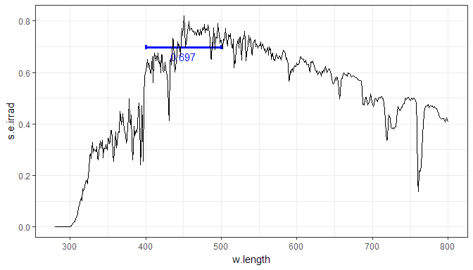

```r
ggplot(sun.spct) +
  stat_wb_hbar(w.band = c(400,500), size = 1.2) +
  stat_wb_mean(aes(color = ..wb.color..),
               w.band = c(400,500), ypos.mult = 0.95) +
  geom_line() +
  scale_color_identity() +
  scale_fill_identity() +
  theme_bw()
```

Lists of wavebands, either user-defined or as in this case using a list constructor can be also used.

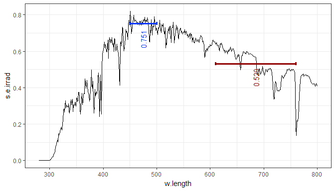

```r
ggplot(sun.spct) +
  geom_line() +
  stat_wb_hbar(w.band = list(Blue(), Red()), size = 1.2) +
  stat_wb_mean(aes(color = ..wb.color..),
               w.band = list(Blue(), Red()), ypos.mult = 0.95,
               hjust = 1, angle = 90) +
  scale_color_identity() +
  scale_fill_identity() +
  theme_bw()
```

### Totals by waveband

Our `stat_wb_total()` is quite different to `ggplot2`s `stat_summary()`. One could criticize that it calculates summaries using a grouping that is not based on a *ggplot* *aesthetic*. This is a deviation from the grammar of graphics but allows the calculation of summaries for an arbitrary waveband of the spectrum based on `photobiology::waveband` objects, or lists of such objects. In contrast to `stat_wl_summary()` this allows the use of several ranges, and also of different weighting functions. This function returns both mean and total values for each waveband. It differs from `stat_wb_mean()` only in the default *aesthetics* set.

The first example uses a `waveband` object created on-the-fly and defining a range of wavelengths.

```r
ggplot(sun.spct) +
  stat_wb_box(w.band = PAR()) +
  stat_wb_total(w.band = PAR()) +
  geom_line() +
  scale_color_identity() +
  scale_fill_identity() +
  theme_bw()
```

[output not shown]

If a numeric vector or a spectrum is supplied as argument to `waveband`, its range is calculated and used to construct a temporary `waveband` object.

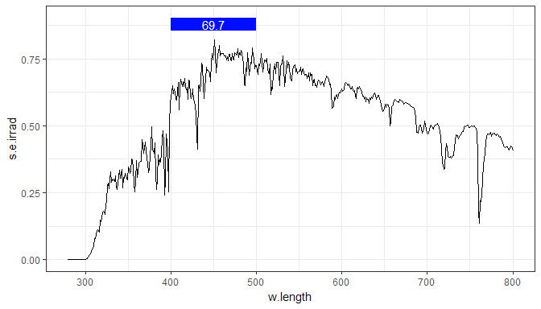

```r
ggplot(sun.spct) +
  stat_wb_box(w.band = c(400,500)) +
  stat_wb_total(w.band = c(400,500)) +
  geom_line() +
  scale_color_identity() +
  scale_fill_identity() +
  theme_bw()
```

Lists of wavebands, either user-defined or as in this case using constructor defined in package `photobiologyWavebands` can be also used. In the case of totals, areas represent them graphically in a very useful way.

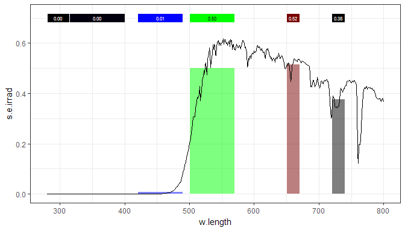

```r
ggplot(sun.spct * yellow_gel.spct) +
  stat_wb_box(w.band = Plant_bands(), color = "white", ypos.fixed = 0.7) +
  stat_wb_column(w.band = Plant_bands(), color = "white", alpha = 0.5) +
  stat_wb_mean(w.band = Plant_bands(), label.fmt = "%1.2f",
               ypos.fixed = 0.7, size = 2) +
  geom_line() +
  scale_fill_identity() + scale_color_identity() +
  theme_bw()
```

### Irradiances by waveband

The _stat_s in previous sections can be used for unweighted irradiances, but not for BSWFs. These `irrad` _stat_s have additional formal parameters for passing metadata, and use method `photobiology::irrad()` internally on a `photobiology::source_spct` object constructed from the data for $x$ and $y$ *aesthetics*. Function `stat_wb_sirrad()` is equivalent to `stat_wb_mean()` and function `stat_wb_irrad()` is equivalent to `stat_wb_total()` following the same naming convention as in package `photobiology`.

```r
ggplot(sun.spct) +
  stat_wb_box(w.band = PAR()) +
  stat_wb_irrad(w.band = PAR(), unit.in = "energy", time.unit = "second") +
  geom_line() +
  scale_color_identity() +
  scale_fill_identity() +
  theme_bw()
```

[output not shown]

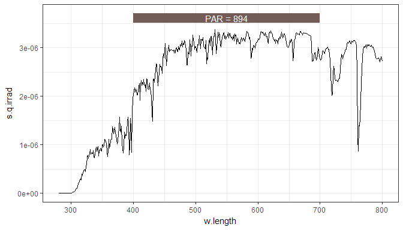

```r
ggplot(sun.spct, unit.out = "photon") +
  stat_wb_box(w.band = PAR()) +
  stat_wb_irrad(w.band = PAR(),
                unit.in = "photon", time.unit = "second",
                aes(label = sprintf("%s = %.3g", ..wb.name.., ..yint.. * 1e6))) +
  geom_line() +
  scale_color_identity() +
  scale_fill_identity() +
  theme_bw()
```

Also following the same naming convention as in package `photobiology`, `e` and `q` versions of these functions default to energy and photon based quantities to `"seconds"` for time unit.

```r
ggplot(sun.spct) +
  stat_wb_box(w.band = PAR()) +
  stat_wb_e_irrad(w.band = PAR()) +
  geom_line() +
  scale_color_identity() +
  scale_fill_identity() +
  theme_bw()
```

[output not shown]

We can also use `waveband` objects describing *biological spectral weighting functions* (BSWFs), such as CIE’s erythema function.

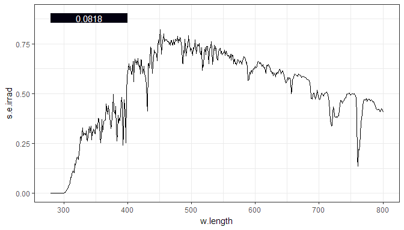

```r
ggplot(sun.spct) +
  stat_wb_box(w.band = CIE()) +
  stat_wb_e_irrad(w.band = CIE()) +
  geom_line() +
  scale_color_identity() +
  scale_fill_identity() +
  theme_bw()
```

For daily data we need to override the default time unit.

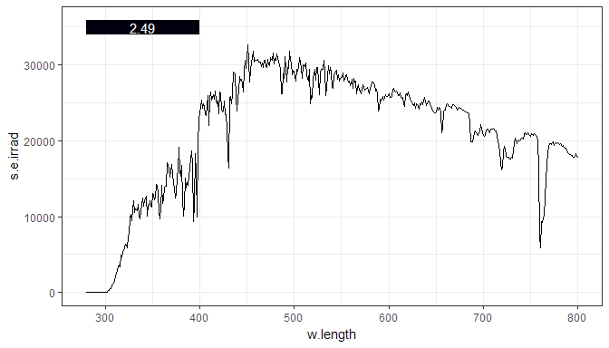

```r
ggplot(sun.daily.spct) +
  stat_wb_box(w.band = CIE()) +
  stat_wb_e_irrad(w.band = CIE(), time.unit = "day", label.mult = 1e-3) +
  geom_line() +
  scale_color_identity() +
  scale_fill_identity() +
  theme_bw()
```

Here we pass a list of `waveband` objects. And add areas to facilitate comparisons as irradiances are intergral over wavelengths.

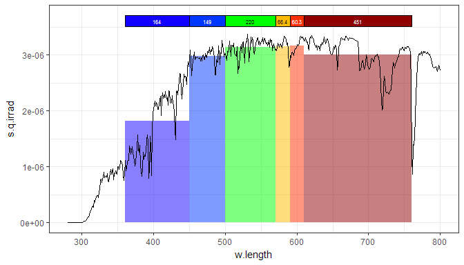

```r
ggplot(sun.spct, unit.out = "photon") +
  stat_wb_box(w.band = VIS_bands(), color = "black") +
  stat_wb_column(w.band = VIS_bands(), color = NA, alpha = 0.5) +
  stat_wb_q_irrad(w.band = VIS_bands(), label.mult = 1e6, size = 2) +
  geom_line() +
  scale_color_identity() +
  scale_fill_identity() +
  theme_bw()
```

### Spectral irradiances by waveband

Spectral irradiances are equivalent to means, and can be best represented graphically as horizontal bars.

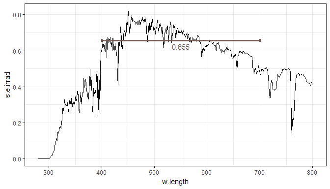

```r
ggplot(sun.spct) +
  geom_line() +
  stat_wb_hbar(w.band = PAR(), size = 1.4) +
  stat_wb_e_sirrad(aes(color = ..wb.color..),
                   w.band = PAR(), ypos.mult = 0.95) +
  scale_color_identity() +
  scale_fill_identity() +
  theme_bw()
```

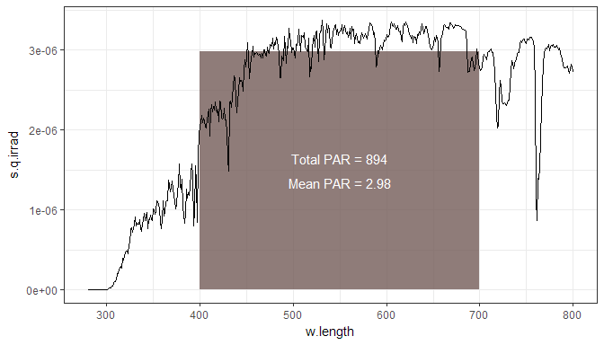

```r
ggplot(sun.spct, unit.out = "photon") +
  stat_wb_column(w.band = PAR(), alpha = 0.8) +
  stat_wb_q_sirrad(w.band = PAR(),
                   mapping =
                     aes(label = sprintf("Total %s = %.3g",
                                         ..wb.name.., ..yint.. * 1e6)),
                   ypos.mult = 0.55) +
  stat_wb_q_sirrad(w.band = PAR(),
                   mapping =
                     aes(label = sprintf("Mean %s = %.3g",
                                         ..wb.name.., ..ymean.. * 1e6)),
                   ypos.mult = 0.45) +
  geom_line() +
  scale_color_identity() +
  scale_fill_identity() +
  theme_bw()
```

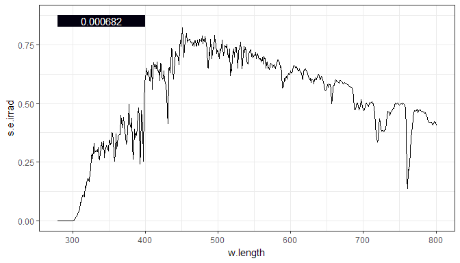

```r
ggplot(sun.spct) +
  stat_wb_box(w.band = waveband(CIE()), ypos.fixed = 0.85) +
  stat_wb_e_sirrad(w.band = CIE(), ypos.fixed = 0.85) +
  geom_line() +
  scale_color_identity() +
  scale_fill_identity() +
  theme_bw()
```

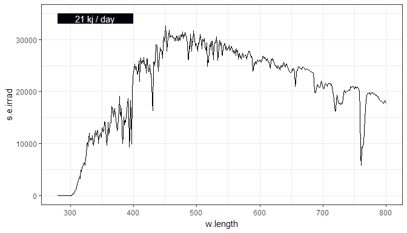

```r
ggplot(sun.daily.spct) +
  stat_wb_box(w.band = waveband(CIE()), ypos.fixed = 34e3) +
  stat_wb_e_sirrad(w.band = CIE(),
                   label.fmt = "%.2g kj / day",
                   time.unit = "day",
                   ypos.fixed = 34e3) +
  geom_line() +
  scale_color_identity() +
  scale_fill_identity() +
  theme_bw()
```

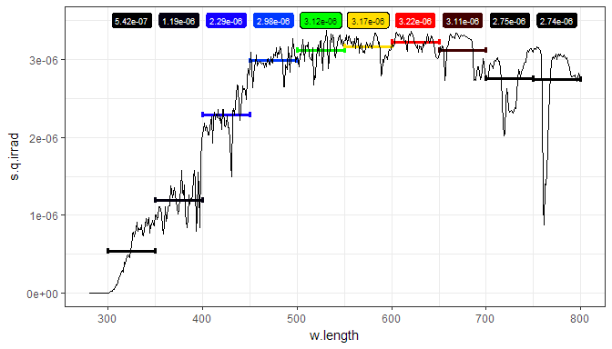

```r
my.bands <- split_bands(c(300,800), length.out = 10)
ggplot(sun.spct, unit.out = "photon") +
  stat_wb_hbar(w.band = my.bands, size = 1.4) +
  stat_wb_q_sirrad(geom = "label", w.band = my.bands,
                   size = 2.5, ypos.fixed = 3.5e-6) +
  geom_line() +
  scale_color_identity() +
  scale_fill_identity() +
  theme_bw()
```

### Irradiances by waveband

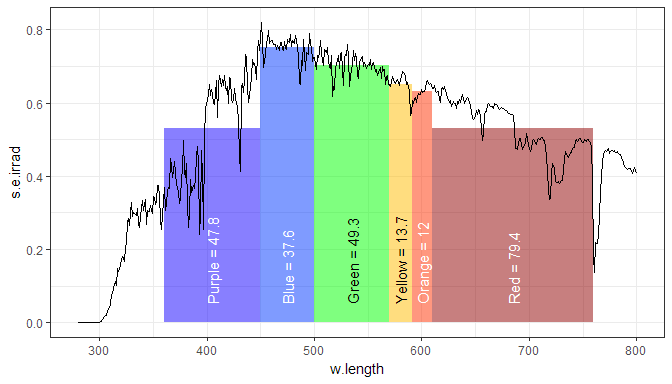

```r
ggplot(sun.spct) +
  stat_wb_column(w.band = VIS_bands(), alpha = 0.5) +
  stat_wb_e_irrad(w.band = VIS_bands(), angle = 90,
                   ypos.fixed = 0.05, hjust = 0,
                   aes(label = paste(..wb.name.., ..y.label.., sep = " = "))) +
  geom_line() +
  scale_color_identity() +
  scale_fill_identity() +
  theme_bw()
```

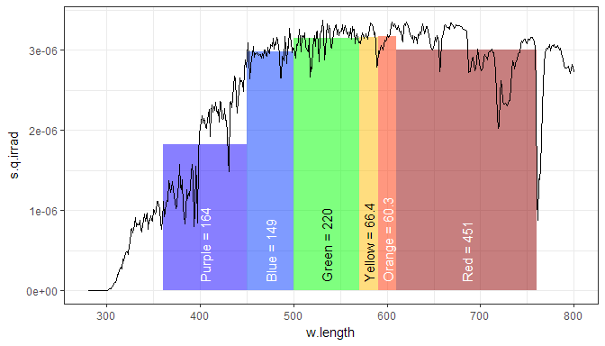

```r
ggplot(sun.spct, unit.out = "photon") +
  stat_wb_column(w.band = VIS_bands(), alpha = 0.5) +
  stat_wb_q_irrad(w.band = VIS_bands(), angle = 90,
                  label.mult = 1e6, ypos.fixed = 1e-7, hjust = 0,
                  aes(label = paste(..wb.name.., ..y.label.., sep = " = "))) +
  geom_line() +
  scale_color_identity() +
  scale_fill_identity() +
  theme_bw()
```

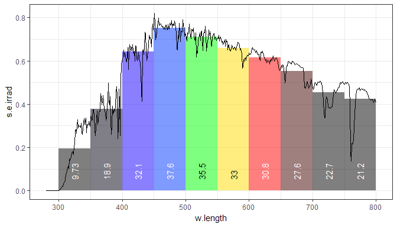

```r
my.bands <- split_bands(c(300,800), length.out = 10)
ggplot(sun.spct) +
  stat_wb_column(w.band = my.bands, alpha = 0.5) +
  stat_wb_e_irrad(w.band = my.bands, angle = 90,
                  ypos.fixed = 0.05, hjust = 0) +
  geom_line() +
  scale_color_identity() +
  scale_fill_identity() +
  theme_bw()
```

## Labels from wavebands

Sometimes we may want to only annotate a plot with waveband names and regions without calculating any summary quantity. `stat_wb_label()` fills this role. Although the same result can be achieved with some of the summary statistics, if no summary is needed this statistic can avoid unnecessary computations, and more importantly used in plots where the $y$ is not mapped, as only the $x$ easthetic is required.

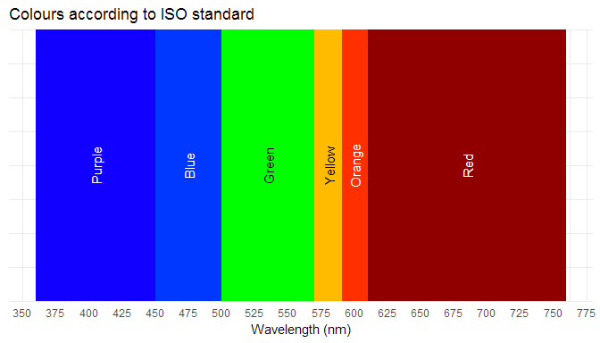

```r
ggplot(data.frame(w.length = 300:800), aes(w.length)) +
  stat_wl_strip(w.band = VIS_bands(), ymax = Inf, ymin = -Inf) +
  stat_wb_label(w.band = VIS_bands(), angle = 90) +
  scale_fill_identity() +
  scale_color_identity() +
  scale_y_continuous(labels = NULL) +
  scale_x_continuous(breaks = seq(from = 300, to = 800, by = 25)) +
  labs(x = "Wavelength (nm)", title = "Colours according to ISO standard") +
  theme_minimal()
```

We can also in a similar way make a plot comparing different sets of wavebands, in the next example we compare the VIS and NIR bands of the different imagers used in Landsat missions 1 to 8.

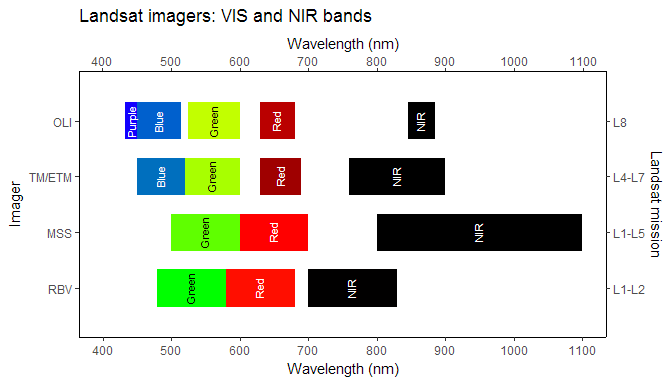

```r
ggplot(data.frame(w.length = 300:1100), aes(w.length)) +
  stat_wl_strip(w.band = RBV_bands(), ymax = 1, ymin = 3) +
  stat_wb_label(w.band = RBV_bands(), ypos.fixed = 2, angle = 90, vjust = 0.3, size = 3) +
  stat_wl_strip(w.band = MSS_bands(), ymax = 4, ymin = 6, na.rm = TRUE) +
  stat_wb_label(w.band = MSS_bands(), ypos.fixed = 5, angle = 90, vjust = 0.3, size = 3) +
  stat_wl_strip(w.band = ETM_bands(), ymax = 7, ymin = 9, na.rm = TRUE) +
  stat_wb_label(w.band = ETM_bands(), ypos.fixed = 8, angle = 90, vjust = 0.3, size = 3) +
  stat_wl_strip(w.band = OLI_bands(), ymax = 10, ymin = 12, na.rm = TRUE) +
  stat_wb_label(w.band = OLI_bands(), ypos.fixed = 11, angle = 90, vjust = 0.3, size = 3) +
  scale_fill_identity() +
  scale_color_identity() +
  scale_y_continuous(labels = c("RBV", "MSS", "TM/ETM", "OLI"),
                     breaks = c(2,5,8,11),
                     limits = c(0, 13),
                     name = "Imager",
                     sec.axis = dup_axis(labels = c("L1-L2", "L1-L5", "L4-L7", "L8"), name = "Landsat mission")) +
  scale_x_continuous(breaks = seq(from = 300, to = 1200, by = 100),
                     limits = c(400, 1100),
                     sec.axis = dup_axis()) +
  labs(x = "Wavelength (nm)", title = "Landsat imagers: VIS and NIR bands") +
  theme_classic()
```

The different definitions of the ulatrviolet regions.

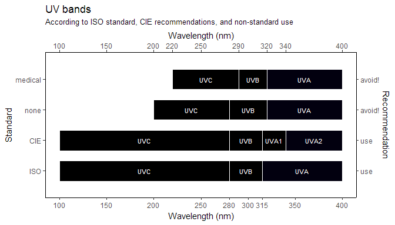

```r
ggplot(data.frame(w.length = 100:400), aes(w.length)) +
  stat_wl_strip(w.band = UV_bands("ISO"), ymax = 1, ymin = 3, color = "white") +
  stat_wb_label(w.band = UV_bands("ISO"), ypos.fixed = 2, size = 3) +
  stat_wl_strip(w.band = UV_bands("CIE"), ymax = 4, ymin = 6, color = "white") +
  stat_wb_label(w.band = UV_bands("CIE"), ypos.fixed = 5, size = 3) +
  stat_wl_strip(w.band = UV_bands("none"), ymax = 7, ymin = 9, color = "white") +
  stat_wb_label(w.band = UV_bands("none"), ypos.fixed = 8, size = 3) +
  stat_wl_strip(w.band = UV_bands("medical"), ymax = 10, ymin = 12, color = "white") +
  stat_wb_label(w.band = UV_bands("medical"), ypos.fixed = 11, size = 3) +

  scale_fill_identity() +
  scale_color_identity() +
  scale_y_continuous(labels = c("ISO", "CIE", "none", "medical"),
                     breaks = c(2,5,8,11),
                     limits = c(0, 13),
                     name = "Standard",
                     sec.axis = dup_axis(labels =
                      c("use", "use", "avoid!", "avoid!"), name = "Recommendation")) +
  scale_x_continuous(breaks = c(seq(from = 100, to = 400, by = 50), 280, 315),
                     limits = c(100, 400),
                     sec.axis =
                       dup_axis(breaks =
                                c(100, 150, 200, 220, 250, 290, 320, 340, 400))) +
  labs(x = "Wavelength (nm)", title = "UV bands",
       subtitle = "According to ISO standard, CIE recommendations, and non-standard use") +
  theme_classic()
```

It should be noted that this approach is rather different from the way one would normally plot a horizontal bar plot with the grammar of graphics of ‘ggplot2’, but for plottings existing waveband definitions it is convenient and ensures that the waveband definitions agree with those used for computing summary quantites elsewhere.

## Wavelength colours at new *x*-values

The `stat_wl_summary()` and `stat_wb_mean()` return a *reduced* data set with fewer rows than the original data. `stat_wl_strip()` depending on the input, can also return a data set with more rows than the input data. This is the default behaviour, with `w.band` with argument `NULL`. This *stat* operates only on the variable mapped to the *x* *aesthetic*, a *y*-mapping is not required as input.

[figure not shown]

```r
my.data <- data.frame(x = 300:800)
ggplot(my.data, aes(x)) + stat_wl_strip(ymin = -1, ymax = 1, color = NA) +
    scale_fill_identity()
```

The default *geom* is `"rect"` which with suitable mappings of `ymin` and `ymax` *aesthetics* can be used to add a colour guide to the *x*-axis (if its scale maps wavelengths in nanometres). When `w.band` is `NULL` a long series of contiguous wavebands is generated to create the illusion of a continuous colour gradient.

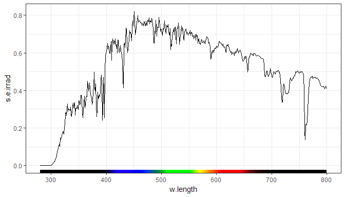

```r
ggplot(sun.spct) +
  geom_line() +
  stat_wl_strip(ymin = -Inf, ymax = -0.025) +
  scale_fill_identity() +
  theme_bw()
```

When a list of wavebands is supplied, it is used for the calculation of colours. These calculations do not use the spectral irradiance, they simply assume a flat spectrum, so the represent the colours of the wavelengths, rather than the colour of the light described by the spectral irradiance.

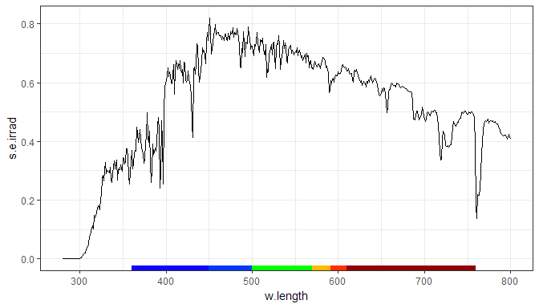

```r
ggplot(sun.spct) +
  geom_line() +
  stat_wl_strip(w.band = VIS_bands(), ymin = -Inf, ymax = -0.025) +
  scale_fill_identity() +
  theme_bw()
```

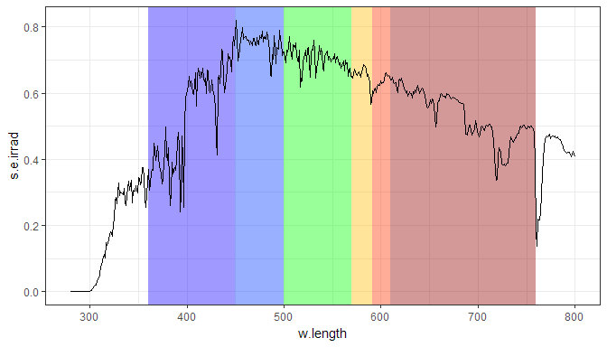

```r
ggplot(sun.spct) +
  stat_wl_strip(w.band = VIS_bands(), ymin = -Inf, ymax = Inf, alpha = 0.4) +
  scale_fill_identity() +
  geom_line() +
  theme_bw()
```

By default an almost continuous colour gradient can be generated for the background.

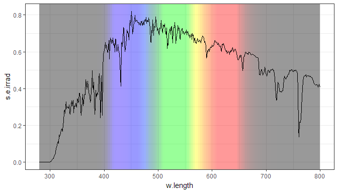

```r
ggplot(sun.spct) +
  stat_wl_strip(alpha = 0.4, ymin = -Inf, ymax = Inf) +
  scale_fill_identity() +
  geom_line() +
  theme_bw()
```

## Multiple stats in the same plot

The *stats* described above can be used together to produce more complex plots. This is just one possibility out of a vast range. Be aware that when adding many layers to the same plot, the order of the layers and adjusting their transparency using the `alpha` *aesthetic* is very important, and best tuned by trial and error.

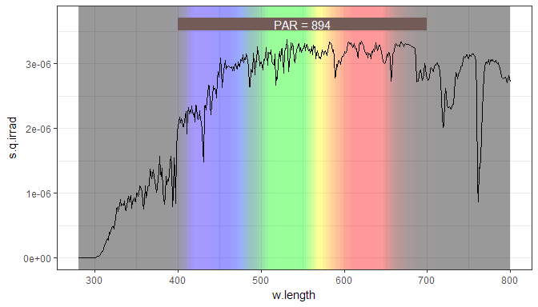

```r
ggplot(sun.spct, unit.out = "photon") +
  stat_wl_strip(alpha = 0.4, ymin = -Inf, ymax = Inf) +
  stat_wb_box(w.band = PAR()) +
  stat_wb_total(w.band = PAR(), label.mult = 1e6,
                aes(label = paste(..wb.name.., " = ", ..y.label.., sep = ""))) +
  geom_line() +
  scale_fill_identity() + scale_color_identity() +
  theme_bw()
```

## Geometries

A simple *geom* called `"spct"` is defined. It differs from *geom* `"area"` only in the default `position` which is `"stacked"` for *geom* `"area"` and `"identity"` for *geom* `"spct"` which is usually better for spectra.

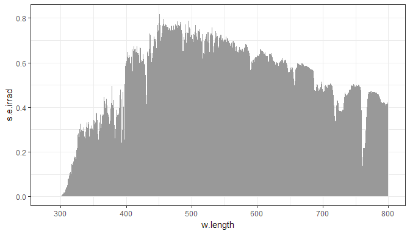

```r
ggplot(sun.spct) + geom_spct()
```

Using as fill the *color* calculated from the spectral data is different to earlier examples in that the spectral irradiance is actually taken into account in the calculation of the colour, instead of just the wavelength range.

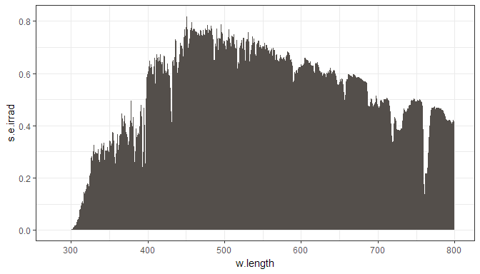

```r
ggplot(sun.spct) +
  geom_spct(fill = color(sun.spct))
```

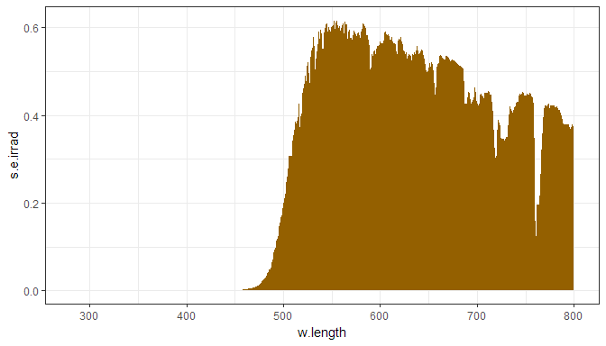

```r
ggplot(sun.spct * yellow_gel.spct) +
  geom_spct(fill = color(sun.spct * yellow_gel.spct))
```

## Packaged stats, geoms plus scales

Some of the examples in previous sections can be simplified by use of `wl_guide()` and `wb_guide()` which add both the statistics and the scale, and provide a default *mapping* for both `ymin` and `ymax`. This is handy for simple plots, but it can generate spurious warnings due to the replacement of existing scales with identical ones. In general only one of `wl_guide()` or `wb_guide()` should be used in a plot, and each one, only once. They just save some typing for the simplest uses, but are not suitable for complex *decorations*.

### wl_guide

The examples for `stat_wl_strip` can be simplified by use of `wl_guide()` which adds both the statistics and the scale, and provides default *mappings* for both `ymin` (`-Inf`) and `ymax` (`Inf`). Another important difference is that the `"rect"` *geom* used cannot be set to a different one by the user.

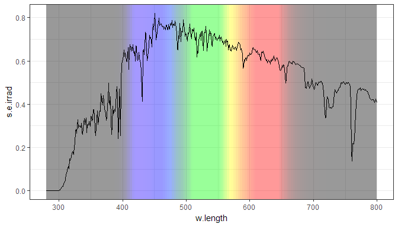

```r
ggplot(sun.spct) +
  wl_guide(alpha = 0.4) +
  geom_line()
```

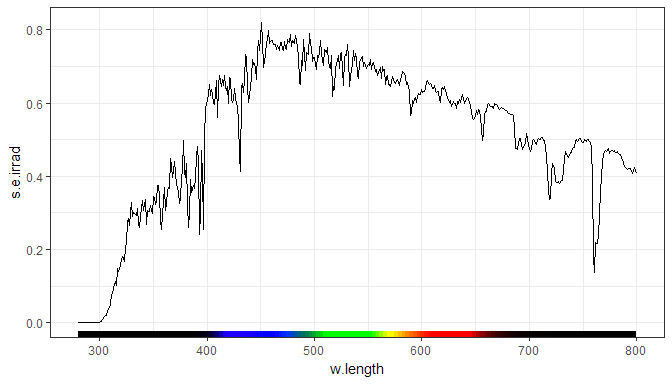

```r
ggplot(sun.spct) +
  wl_guide(ymax = -0.025) +
  geom_line()
```

This example produces a plot with a very different look than earlier ones, but can also be achieved with a very succinct statement.

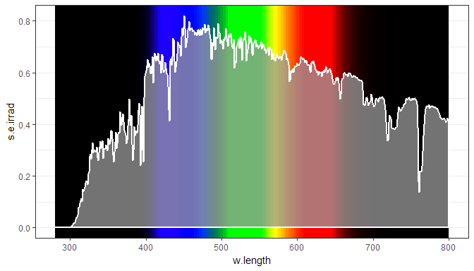

```r
ggplot(sun.spct) +
  wl_guide() +
  geom_spct(alpha = 0.75, colour = "white", size = 1)
```

In the next example we demonstrate a trick achieved by overploting two line of different width (`size`) to make the spectrum visible on a background of variable luminosity.

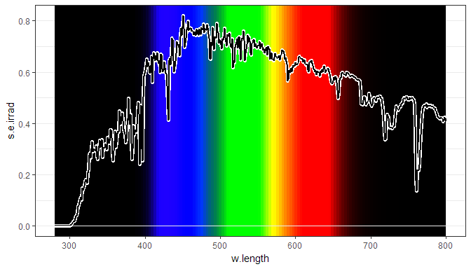

```r
ggplot(sun.spct) +
  wl_guide() +
  geom_line(size = 2, colour = "white") +
  geom_line(size = 1, colour = "black") +
  geom_hline(yintercept = 0, colour = "grey92") +
  theme_bw()
```

## Color charts

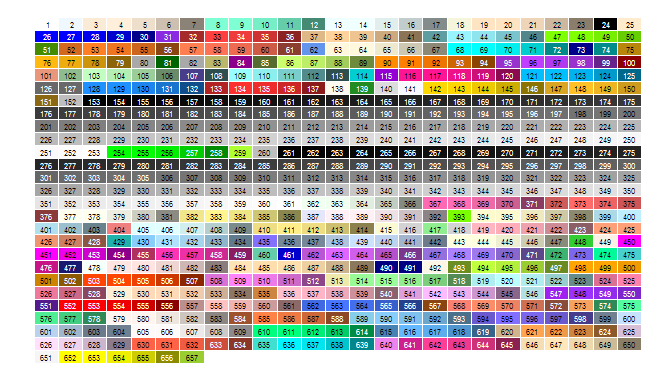

```r
color_chart(colors())
```

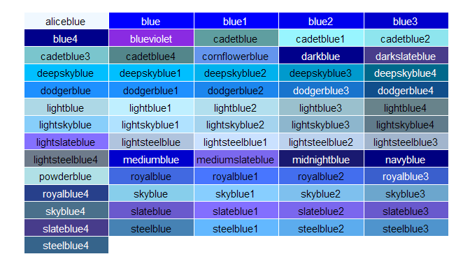

```r
color_chart(grep("blue", colors(), value = TRUE), ncol = 5, text.size = 4)
```

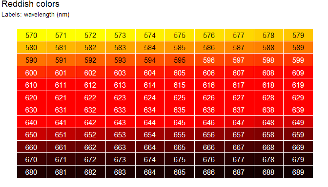

```r
 color_chart(w_length2rgb(570:689, color.name = as.character(570:689)),
            use.names = TRUE, text.size = 4) +
  ggtitle("Reddish colors", subtitle = "Labels: wavelength (nm)")
```